# ncappc report[^1]

# 1 Results Summary

**Arguments passed to the *ncappc* function:**

ncappc(obsFile = rawpk, str1Nm = “IND”, str1 = c(0, 1), concUnit = “ng/ml”, timeUnit = “hours”, doseUnit = “ng”, idNmObs = “ID”, timeNmObs = “TAD”, concNmObs = “DV”, onlyNCA = TRUE, LambdaTimeRange = “NULL”, doseAmtNm = “DOSE”, method = “linearup-logdown”, studyName = “PK Tutorial”, outFileNm = “WOW_PK_TUTORIAL”, gg_theme = theme_classic(), extrapolate = TRUE)

**Data, settings and results:**

```
Main directory:  /Users/gabrielteku/Documents/r-pharmacokinetics
```

```
Name of the study: "PK Tutorial"
Name of the file with the observed data: "rawpk"
Route of administration: extravascular
Dose type: non-steady-state
No. of population stratification levels: 1
Population stratification column: IND
Population stratification ID within IND: 0, 1
```

Table 1.1: Dataset summary

| IND | Dose (ng) | No. of individuals |
| --- | --- | --- |
| 0 | 20000000 | 12 |
| 1 | 20000000 | 12 |

# 2 Tabular output

A number of tables are produced from the *ncappc* tool and are found in the same directory as this report. Descriptions of these tables are below. All tables are produced as tab separated value (.tsv) files, *i.e.*, the columns in the tables are separated by tabs. “NaN” or “NA” is produced if a metric or value is irrelevant for a specified data type or case.

**ncaOutput.tsv:** The estimated values of the NCA metrics for each individual along with other stratifiers (eg. population group ID, dose ID, etc.) if specified in the input command.

Table 2.1: A representative portion of the table ncaOutput.tsv.

| ID | IND | Dose | AUClast | Cmax | Tmax | AUCINF_obs | Vz_obs | Cl_obs | HL_Lambda_z |
| --- | --- | --- | --- | --- | --- | --- | --- | --- | --- |
| 1 | 0 | 20000000 | 6.121667 | 1.285012 | 2.0 | 6.342291 | 10098126 | 3153435 | 2.219639 |
| 1 | 1 | 20000000 | 4.194659 | 1.120506 | 1.5 | 4.222845 | 10125792 | 4736144 | 1.481937 |
| 2 | 0 | 20000000 | 7.631285 | 1.377428 | 2.0 | 8.251400 | 10091110 | 2423831 | 2.885772 |
| 2 | 1 | 20000000 | 5.549599 | 1.241616 | 2.0 | 5.684378 | 10103015 | 3518415 | 1.990350 |
| 3 | 0 | 20000000 | 5.398718 | 1.229154 | 2.0 | 5.515540 | 10104627 | 3626119 | 1.931540 |
| 3 | 1 | 20000000 | 3.916895 | 1.098352 | 1.5 | 3.935281 | 10134197 | 5082229 | 1.382167 |
| 4 | 0 | 20000000 | 8.085249 | 1.400598 | 2.0 | 8.888235 | 10090015 | 2250166 | 3.108156 |
| 4 | 1 | 20000000 | 5.075082 | 1.200761 | 2.0 | 5.159179 | 10108675 | 3876586 | 1.807467 |
| 5 | 0 | 20000000 | 6.752459 | 1.326959 | 2.0 | 7.105706 | 10094398 | 2814639 | 2.485897 |
| 5 | 1 | 20000000 | 5.095868 | 1.202658 | 2.0 | 5.181844 | 10108387 | 3859630 | 1.815355 |
| 6 | 0 | 20000000 | 5.848361 | 1.264993 | 2.0 | 6.024278 | 10100245 | 3319900 | 2.108786 |
| 6 | 1 | 20000000 | 4.208989 | 1.121588 | 1.5 | 4.237767 | 10125410 | 4719467 | 1.487117 |
| 7 | 0 | 20000000 | 5.110324 | 1.203971 | 2.0 | 5.197623 | 10108190 | 3847913 | 1.820848 |
| 7 | 1 | 20000000 | 3.012651 | 1.005984 | 1.5 | 3.015572 | 10184677 | 6632241 | 1.064418 |
| 8 | 0 | 20000000 | 8.173193 | 1.404891 | 2.0 | 9.015633 | 10089840 | 2218369 | 3.152652 |
| 8 | 1 | 20000000 | 7.119951 | 1.349063 | 2.0 | 7.572025 | 10092802 | 2641301 | 2.648618 |
| 9 | 0 | 20000000 | 4.934721 | 1.187674 | 2.0 | 5.006887 | 10110724 | 3994498 | 1.754468 |
| 9 | 1 | 20000000 | 3.774952 | 1.086088 | 1.5 | 3.789436 | 10139365 | 5277830 | 1.331622 |
| 10 | 0 | 20000000 | 5.792976 | 1.260783 | 2.0 | 5.960681 | 10100720 | 3355321 | 2.086621 |
| 10 | 1 | 20000000 | 3.595961 | 1.069592 | 1.5 | 3.606443 | 10146955 | 5545631 | 1.268266 |
| 11 | 0 | 20000000 | 6.441543 | 1.306970 | 2.0 | 6.723964 | 10096058 | 2974436 | 2.352733 |
| 11 | 1 | 20000000 | 4.119151 | 1.114708 | 1.5 | 4.144367 | 10127882 | 4825827 | 1.454696 |
| 12 | 0 | 20000000 | 5.625402 | 1.247706 | 2.0 | 5.769897 | 10102262 | 3466266 | 2.020143 |
| 12 | 1 | 20000000 | 3.981722 | 1.103732 | 1.5 | 4.002127 | 10132050 | 4997343 | 1.405347 |

**ObsStat.tsv:** A set of statistical parameters calculated for the entire population or the stratified population for the following NCA metrics estimated from the *observed data*: Stat, C0, Tmax, Cmax, Cmax_D, Tlast, Clast, AUClast, AUMClast, MRTlast, No_points_Lambda_z, AUC_pBack_Ext_obs, AUC_pBack_Ext_pred, AUClower_upper, Rsq, Rsq_adjusted, Corr_XY, Lambda_z, HL_Lambda_z, AUCINF_obs, AUCINF_D_obs, AUC_pExtrap_obs, Vz_obs, Cl_obs, AUCINF_pred, AUCINF_D_pred, AUC_pExtrap_pred, Vz_pred, Cl_pred, AUMCINF_obs, AUMC_pExtrap_obs, AUMCINF_pred, AUMC_pExtrap_pred, MRTINF_obs, MRTINF_pred, Vss_obs, Vss_pred, Tau, Tmin, Cmin, Cavg, p_Fluctuation, Accumulation_Index, Clss. Calculated statistical parameters: **Ntot:** Total number of data points, **Nunique:** number of unique data points, **Min:** minimum value, **Max:** maximum value, **Mean:** mean/average value, **SD:** standard deviation, **SE:** standard error, **CVp:** coefficient of variation in percent, **a95CIu:** upper limit of 95% arithmetic confidence interval, **a95CIl:** lower limit of 95% arithmetic confidence interval, **gMean:** geometric mean, **gCVp:** geometric coefficient of variation in percent.

Table 2.2: A representative portion of the table ObsStat.tsv.

| IND | Stat | C0 | Tmax | Cmax | Cmax_D | Tlast | Clast | AUClast |
| --- | --- | --- | --- | --- | --- | --- | --- | --- |
| 0 | N | NA | 12.00 | 12.00 | 12.00 | 12.00 | 12.00 | 12.00 |
| 0 | Nunique | NA | 1.000 | 12.00 | 12.00 | 1.000 | 12.00 | 12.00 |
| 0 | Min | NA | 2.000 | 1.188 | 0.00000005938 | 12.00 | 0.02851 | 4.935 |
| 0 | Max | NA | 2.000 | 1.405 | 0.00000007024 | 12.00 | 0.1852 | 8.173 |
| 0 | Mean | NA | 2.000 | 1.291 | 0.00000006457 | 12.00 | 0.08588 | 6.326 |
| 0 | Median | NA | 2.000 | 1.275 | 0.00000006375 | 12.00 | 0.06336 | 5.985 |
| 0 | SD | NA | 0 | 0.07359 | 0.000000003680 | 0 | 0.05559 | 1.117 |
| 0 | SE | NA | 0 | 0.02124 | 0.000000001062 | 0 | 0.01605 | 0.3224 |
| 0 | CVp | NA | 0 | 5.699 | 5.699 | 0 | 64.73 | 17.66 |
| 0 | CI95l | NA | 2.000 | 1.245 | 0.00000006223 | 12.00 | 0.05056 | 5.617 |
| 0 | CI95u | NA | 2.000 | 1.338 | 0.00000006691 | 12.00 | 0.1212 | 7.036 |
| 0 | geoMean | NA | 2.000 | 1.289 | 0.00000006447 | 12.00 | 0.07145 | 6.240 |
| 0 | gCVp | NA | 0 | 5.667 | 5.667 | 0 | 69.87 | 17.30 |
| 1 | N | NA | 12.00 | 12.00 | 12.00 | 12.00 | 12.00 | 12.00 |
| 1 | Nunique | NA | 2.000 | 12.00 | 12.00 | 1.000 | 12.00 | 12.00 |
| 1 | Min | NA | 1.500 | 1.006 | 0.00000005030 | 12.00 | 0.001902 | 3.013 |
| 1 | Max | NA | 2.000 | 1.349 | 0.00000006745 | 12.00 | 0.1183 | 7.120 |
| 1 | Mean | NA | 1.667 | 1.143 | 0.00000005714 | 12.00 | 0.02528 | 4.470 |
| 1 | Median | NA | 1.500 | 1.118 | 0.00000005588 | 12.00 | 0.01260 | 4.157 |
| 1 | SD | NA | 0.2462 | 0.09135 | 0.000000004567 | 0 | 0.03223 | 1.092 |

# 3 Graphical output

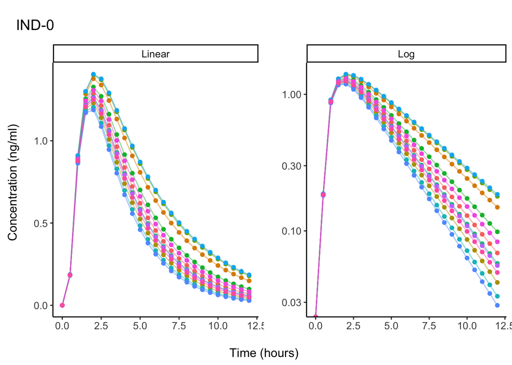

Figure 3.1: Concentration vs. time profile for each individual (stratified by dose or population group, if any). The left panel shows the concentration data on the linear scale, while the right panel shows the concentration data on semi-logarithmic scale.

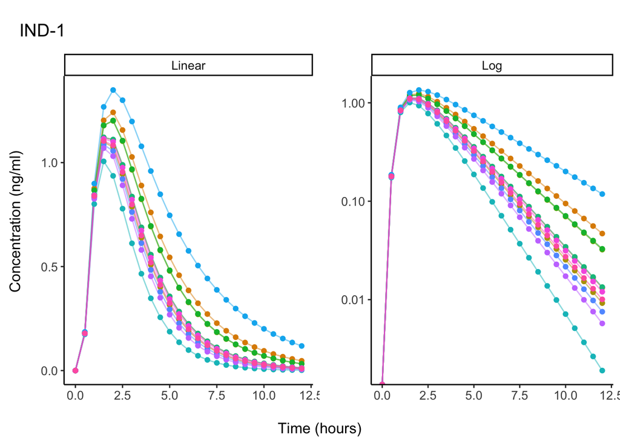

Figure 3.2: (Continued) Concentration vs. time profile for each individual (stratified by dose or population group, if any).

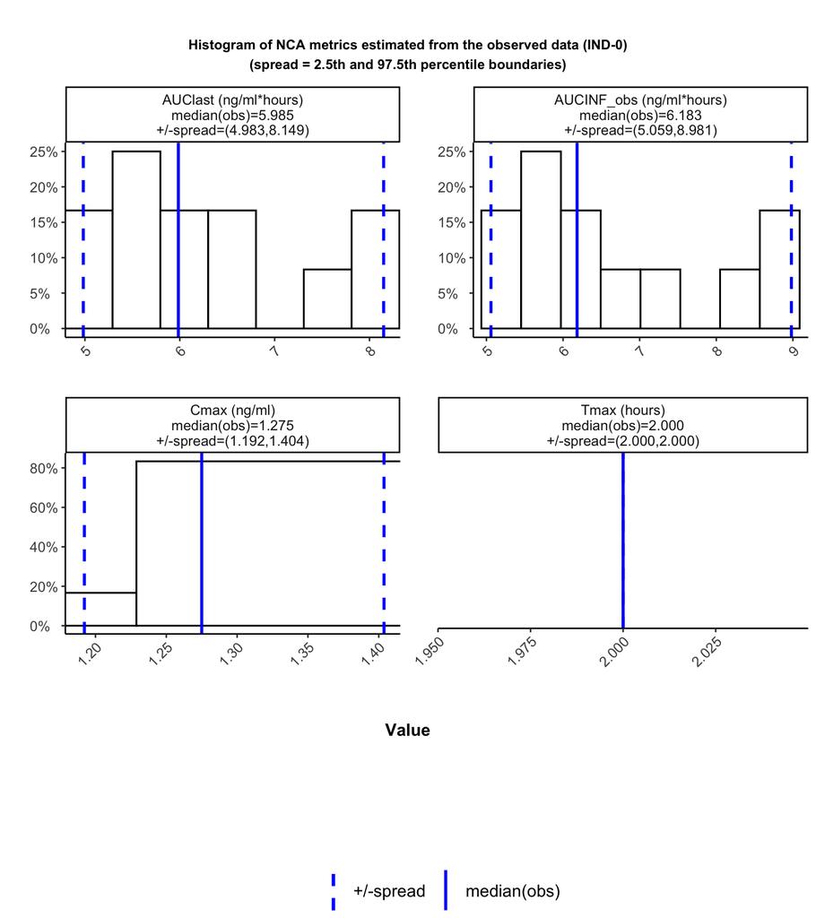

Figure 3.3: [Population level] Histogram of four selected NCA metrics (AUClast, AUCINF_obs, Cmax, Tmax) estimated from the observed data. The solid blue vertical and dotted lines represent the population median and the “spread” of the data. The “spread” is defined by 95% nonparametric prediction interval of the NCA metrics obtained from the observed data.

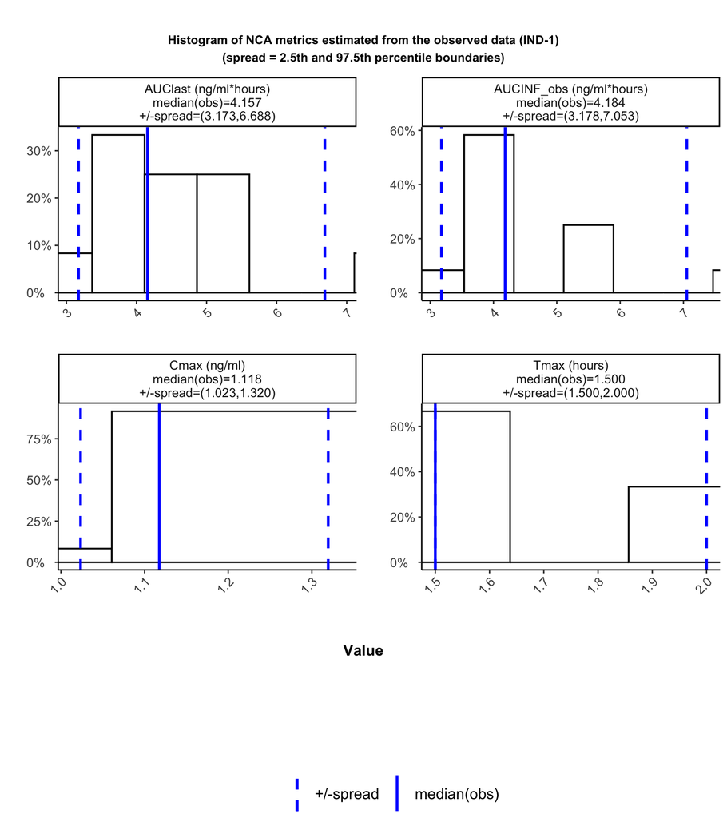

Figure 3.4: [Population level] Histogram of four selected NCA metrics (AUClast, AUCINF_obs, Cmax, Tmax) estimated from the observed data. The solid blue vertical and dotted lines represent the population median and the “spread” of the data. The “spread” is defined by 95% nonparametric prediction interval of the NCA metrics obtained from the observed data.

[^1]: Acharya, C., Hooker, A. C., Turkyilmaz, G. Y., Jonsson, S., Karlsson, M. O.; A diagnostic tool for population models using non-compartmental analysis: The ncappc package for R, *Computer Methods and Programs in Biomedicine*, 2016, Vol. 127, 83-93